# OceanColor Data Products and R

This is a quick analysis and demo for downloading and importing global oceancolor products (e.g SST, Chl-a) available from [NASA's OceanColor Web](http://oceancolor.gsfc.nass.gov) into R for mapping and analysis. The steps and tools described here are only guaranteed, at this point, to work within an OS X environment. That said, the tools used are available for other platforms and should be easily adapted.

### Required Software and Tools

- R 2.15.0
- GDAL 1.9 Complete frameworks available from [KyngChaos](http://www.kyngchaos.com/software/frameworks)
- rgdal 0.7.8-2 binary available from [KyngChaos](http://www.kyngchaos.com/software/frameworks)
- gdal programs must be available on the users path

### Load R Packages

```r
# if necessary uncomment and install packages.  install.packages('sp')
# install.packages('rgeos') install.packages('raster')
# install.packages('RCurl') install.packages('ggplot2')
library(sp)
library(rgdal)
library(rgeos)
library(raster)
library(RCurl)
library(ggplot2)
```

### Get 8-day composite SST (daytime 11$\mu$m) and unzip

First, we'll connect to the OceanColor website to download an example SST file. The [OceanColor Web](http://oceancolor.gsfc.nasa.gov) provides a web user interface for finding and downloading data from various MODIS and SeaWIFS satellite sensors. Users can find and download files into a single directory and the `OC2Raster` function (in development) will process all files within the directory. Files must be Level 3, SMI of HDF filetype.

```r
# eventually, we'll add the ability to specify date, data range and
# resolution
download.file("http://oceandata.sci.gsfc.nasa.gov/cgi/getfile/A20121212012128.L3m_8D_SST_4.bz2",
    "A20121212012128.L3m_8D_SST_4.bz2")

cmd <- paste("bunzip2", "A20121212012128.L3m_8D_SST_4.bz2")
system(cmd)
```

#### Extract valuable metadata for this image

We need to extract the following values from the metadata:

- Westernmost Longitude (`min_lon`)
- Northernmost Latitude (`max_lat`)
- Easternmost Longitude (`max_lon`)
- Southernmost Latitude (`min_lat`)
- Map Projection (`map_proj`)
- Parameter (`param`)
- Period End Day (`day_end`)
- Period Start Day (`day_start`)
- Period End Year (`year_end`)
- Period Start Year (`year_start`)
- Suggested Image Scaling Applied (`scaled`)
- Scaling (`scaling`)
- Slope (`slope`)
- Intercept (`intercept`)

It should be easy enough to create our own function, `XtrMdata` to pull these values out from the metadata and return a named list

```r
XtrMdata <- function(gdal_obj) {
    require(rgdal)
    info <- GDALinfo(gdal_obj)
    attrs <- c("Westernmost Longitude=", "Northernmost Latitude=", "Easternmost Longitude=",
        "Southernmost Latitude=", "Map Projection=", "Parameter=", "Period End Day=",
        "Period Start Day=", "Period End Year=", "Period Start Year=", "Suggested Image Scaling Applied=",
        "Scaling=", "Slope=", "Intercept=")
    var_names <- c("min_lon", "max_lat", "max_lon", "min_lat", "map_proj", "param",
        "day_end", "day_start", "year_end", "year_start", "scaled", "scaling",
        "slope", "intercept")
    i <- as.numeric(sapply(attrs, function(y) grep(y, attr(info, "mdata"))[1]))
    j <- sapply(i, function(y) unlist(strsplit(attr(info, "mdata")[y], "="))[2])
    j <- as.list(j)
    names(j) <- var_names
    return(j)
}
```

Now that we have our function, let's apply it to our downloaded OceanColor hdf

```r
mdata <- XtrMdata("A20121212012128.L3m_8D_SST_4")
# now, we'll convert to data.frame and transpose for pretty printing
mdata_t <- t(data.frame(mdata))
colnames(mdata_t) <- c("values")
mdata_t
```

```
##            values
## min_lon    "-180"
## max_lat    "90"
## max_lon    "180"
## min_lat    "-90"
## map_proj   "Equidistant Cylindrical"
## param      "Sea Surface Temperature"
## day_end    "128"
## day_start  "121"
## year_end   "2012"
## year_start "2012"
## scaled     "Yes"
## scaling    "linear"
## slope      "0.000717185"
## intercept  "-2"
```

In order to translate the hdf file into a GeoTIFF, we have to make some assumptions:  
1. The map projection is “Equidistant Cylindrical”  
2. The extent of the grid is global  
3. The values have been linearly scaled

So, let's check that these assumptions are met

```
## Equidistant Cylindrical .... TRUE
```

```
## Global Coverage .... TRUE
```

```
## Linear Scaling .... TRUE
```

Now that we have satisfied all of our assumptions, we're ready to have `gdal_translate` convert the file from hdf to GeoTIFF and assign the correct projection

```r
in_hdf <- "A20121212012128.L3m_8D_SST_4"
out_tiff <- "A20121212012128.L3m_8D_SST_4.tif"
cmd <- paste("gdal_translate -a_srs \"+init=epsg:32662\" -a_ullr -180 90 180 -90 -a_nodata 65535 HDF4_SDS:UKNOWN:\"",
    in_hdf, "\":0 ", out_tiff, sep = "")
system(cmd)
```

Now, we can read the newly created GeoTIFF into R as a `RasterLayer` object from the `raster` package. The `raster` package is more efficient than reading in the readGDAL (rgdal package) because it does not read all of the values into memory until needed.

```r
sst_raster <- raster(out_tiff)
sst_raster
```

```
## class       : RasterLayer
## dimensions  : 4320, 8640, 37324800  (nrow, ncol, ncell)
## resolution  : 0.04167, 0.04167  (x, y)
## extent      : -180, 180, -90, 90  (xmin, xmax, ymin, ymax)
## coord. ref. : +proj=eqc +lat_ts=0 +lat_0=0 +lon_0=0 +x_0=0 +y_0=0 +datum=WGS84 +units=m +no_defs +ellps=WGS84 +towgs84=0,0,0
## values      : /Users/josh.london/Arr/scratch/A20121212012128.L3m_8D_SST_4.tif
## min value   : 0
## max value   : 65535
## layer name  : A20121212012128.L3m_8D_SST_4
##
```

If we examine the data values stored within the `RasterLayer`, we'll notice that reported values are not reasonable for expected SST in degrees Celcius … in fact, the values are more appropriate for SST on Mercury. This is because the values have been linearly scaled to fit with the limits of the unsigned 16-bit integer. The scaling is a linear equation with slope and intercept values stored as metadata in the original HDF. We've previously extracted the values and stored them as `slope` (=`0.000717185`) and `intercept` (=`-2`).

First, here's the summary output for `sst_raster`. Note, the `getValues` function is used to retrieve the values for the `RasterLayer` since, by default, the values are not read into memory.

```r
summary(getValues(sst_raster))
```

```
##     Min.  1st Qu.   Median     Mean  3rd Qu.     Max.     NA's
##        0    11700    30900    26500    40200    52500 18876446
```

Next, we'll apply our linear scaling equation to all the scaled values and use the `setValues` function to replace with the corresponding SST values.

```r
sst_raster <- setValues(sst_raster, as.numeric(mdata$slope) * getValues(sst_raster) +
    as.numeric(mdata$intercept))
```

And, a plot of the raster

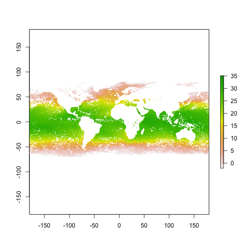

```r
plot(sst_raster)
```